# Nigerian-TCGA Differential Expression Analysis Using DeSeq2

Padma Sheila Rajagopal, MD MPH

1/12/2019

```r
library("DESeq2")
library(stringi)
library("dplyr")
```

```r
library("ggplot2")
library("hexbin")
library("AnnotationDbi")
library("org.Hs.eg.db")
library('GenomicFeatures')
library(biomaRt)
library (EnsDb.Hsapiens.v75)
library(apeglm)
library("genefilter")
library(pheatmap)
library("sva")
setwd("~/Research-Local/RNAseq-Local/Inputs/NigerianTCGA_quants")
```

I have 86 TCGA patients with whole-genome sequencing data and RNAseq data as well as 99 Nigerian patients with RNA-seq data. Raw counts were initially processed using HTSeq, so HTSeq data is being formatted for use with DESeq2.

```r
FOLDER <- "/Users/parajago/Research-Local/RNAseq-Local/Inputs/NigerianTCGA_quants"

sampleFiles <- grep("htseq.counts",list.files(FOLDER),value=TRUE)
sampleCondition <- sub("(.*LIB).*","\\1",sampleFiles)

#Differential gene expression setup for TCGA (all) + Nigerian
#countVar=1
#for (sample in sampleCondition){
#  if (grepl(sample,"LIB")==TRUE){
#    sampleCondition[countVar] <- "Nigerian"
#    countVar=countVar+1
#  }else{
#    sampleCondition[countVar] <- "TCGA"
#    countVar=countVar+1
#  }
#}

#sampleTable <- data.frame(sampleName=gsub(".htseq.counts","",sampleFiles),
#                          fileName=sampleFiles,
#                          condition=sampleCondition)

#ddsHTSeq <- DESeqDataSetFromHTSeqCount(sampleTable=sampleTable,
#                                       directory=FOLDER,
#                                       design=~condition)

#Differential gene expression setup based on race (b/w/other)
sampleConditionrace <- sampleFiles
countVar2=1
for (sample in sampleConditionrace){
  if (stri_detect_fixed(sample,"LIB")==TRUE){
    sampleConditionrace[countVar2] <- "Nigerian"
    countVar2=countVar2+1
  } else if (stri_detect_fixed(sample,"black")==TRUE){
    sampleConditionrace[countVar2] <- "TCGA_black"
    countVar2=countVar2+1
  } else if (stri_detect_fixed(sample,"white")==TRUE){
    sampleConditionrace[countVar2] <- "TCGA_white"
    countVar2=countVar2+1
  } else{
    sampleConditionrace[countVar2] <- "TCGA_other"
    countVar2=countVar2+1
  }
}

sampleTable2 <- data.frame(sampleName=gsub(".htseq.counts","",sampleFiles),
                          fileName=sampleFiles,
                          condition=sampleConditionrace)

ddsHTSeqMF <- DESeqDataSetFromHTSeqCount(sampleTable=sampleTable2,
                                       directory=FOLDER,
                                       design=~condition)
```

I am now running initial variance transformations and plotting count data with a PCA.

```r
nrow(ddsHTSeqMF)
```

```
## [1] 57820
```

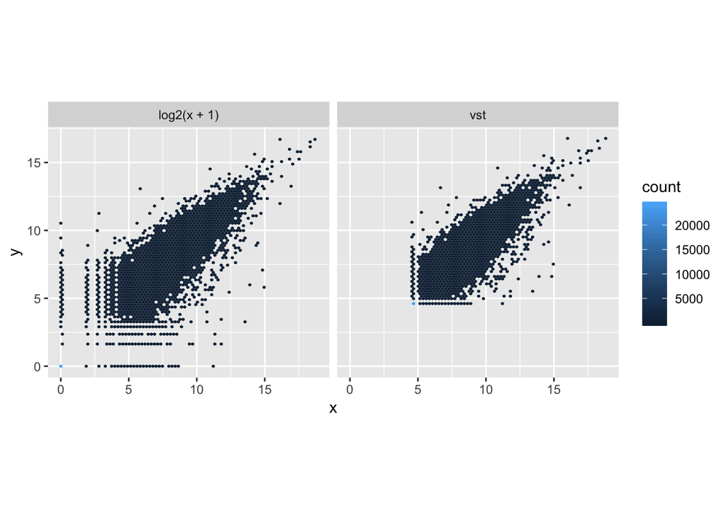

```r
ddsHTSeqMF <- ddsHTSeqMF[rowSums(counts(ddsHTSeqMF)) > 1, ] #Pre-filtering the dataset by removing the rows without information about gene expression

vsd <- vst(ddsHTSeqMF, blind = TRUE) #Variance-stabilizing transformation

# Plotting transformed counts. Differences between patients and condition WILL contribute to the expected variance-mean trend of the experiment. This represents a fully unsupervised transformation, one can set blind = TRUE (which is the default).

dds <- estimateSizeFactors(ddsHTSeqMF)
#The size factor is the median ratio of the sample over a "pseudosample":
#for each gene, the geometric mean of all samples.

df <- bind_rows(
          as_data_frame(log2(counts(dds, normalized=TRUE)[, 1:2]+1)) %>%
          mutate(transformation = "log2(x + 1)"),
          as_data_frame(assay(vsd)[, 1:2]) %>% mutate(transformation = "vst"))
          colnames(df)[1:2] <- c("x", "y")

ggplot(df, aes(x = x, y = y)) + geom_hex(bins = 80) +
  coord_fixed() + facet_grid( . ~ transformation)
```

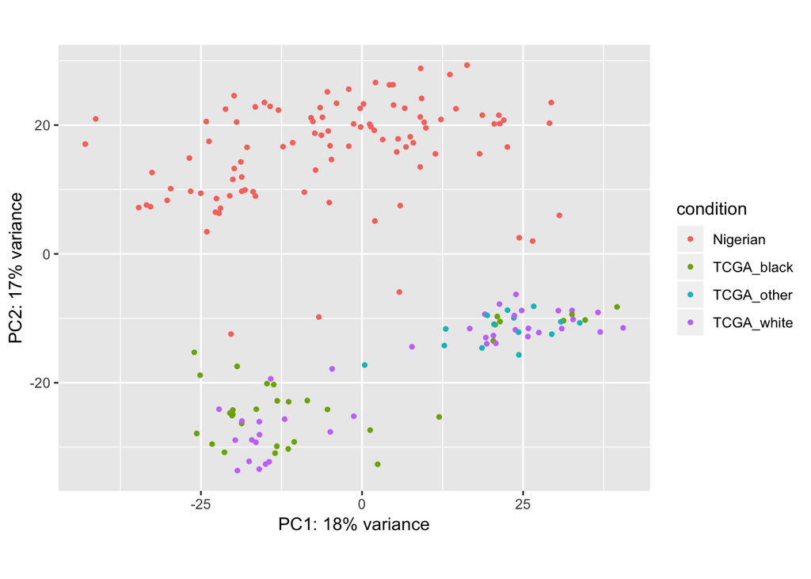

```r
pcaData <- plotPCA(vsd, intgroup = c("condition"), returnData = TRUE)
percentVar <- round(100 * attr(pcaData, "percentVar"))

ggplot(pcaData, aes(x = PC1, y = PC2, color = condition)) +
  geom_point(size =1) +
  xlab(paste0("PC1: ", percentVar[1], "% variance")) +
  ylab(paste0("PC2: ", percentVar[2], "% variance")) +
  coord_fixed()
```

This is the actual differential expression analysis with false discovery threshold of 0.05. Then we are sorting out the results for both the white and black TCGA patients separately. Differential expression results are annotated.

```r
ddsMF <- DESeq(ddsHTSeqMF)
```

```
## -- replacing outliers and refitting for 8349 genes
## -- DESeq argument 'minReplicatesForReplace' = 7
## -- original counts are preserved in counts(dds)
```

```r
#Produce results with the false-discovery threshold of 0.05 with the Nigerian patients in the numerator of the ratio and the TCGA patients in the denominator
reswhiteNigerian <- results(ddsMF, contrast=c("condition","Nigerian","TCGA_white"), alpha=0.05)
resblackNigerian <- results(ddsMF, contrast=c("condition","Nigerian","TCGA_black"), alpha=0.05)
#summary(reswhiteNigerian)
#summary(resblackNigerian)

#Output of results
#DataFrame with 6 rows and 2 columns
#                       type                                        description
#                <character>                                        <character>
#baseMean       intermediate          mean of normalized counts for all samples, average of the normalized count values, divided by the size factors, taken over all samples in the DESeqDataSet.
#log2FoldChange      results log2 fold change (MLE): condition TCGA vs Nigerian, effect size estimate
#lfcSE               results         standard error: condition TCGA vs Nigerian
#stat                results         Wald statistic: condition TCGA vs Nigerian
#pvalue              results      Wald test p-value: condition TCGA vs Nigerian
#padj                results                               BH adjusted p-values

resSigwhite <- subset(reswhiteNigerian, padj < 0.05)
resSigblack <- subset(resblackNigerian, padj < 0.05) #Puts all significantly differentially expressed genes into a table

#Provided method for annotating genes from Bioconductor/DESeq2
txdb <- makeTxDbFromBiomart(biomart="ENSEMBL_MART_ENSEMBL",
                     dataset="hsapiens_gene_ensembl",
                     transcript_ids=NULL,
                     circ_seqs=DEFAULT_CIRC_SEQS,
                     filter=NULL,
                     id_prefix="ensembl_",
                     host="www.ensembl.org",
                     port=80,
                     taxonomyId=NA,
                     miRBaseBuild=NA)
```

```
## Download and preprocess the 'transcripts' data frame ...
```

```
## OK
```

```
## Download and preprocess the 'chrominfo' data frame ... OK
## Download and preprocess the 'splicings' data frame ... OK
## Download and preprocess the 'genes' data frame ... OK
## Prepare the 'metadata' data frame ... OK
## Make the TxDb object ... OK
```

```r
mart = useMart("ensembl", dataset=
                      "hsapiens_gene_ensembl")

resSigwhite$temp <- row.names(resSigwhite)
resSigwhite$temp <- gsub("[.].+", "", resSigwhite$temp)

resSigwhite$symbol <- mapIds(EnsDb.Hsapiens.v75,
                     keys=resSigwhite$temp,
                     column="SYMBOL",
                     keytype="GENEID",
                     multiVals="first")

resSigwhite$biotype <- mapIds(EnsDb.Hsapiens.v75,
                     keys=resSigwhite$temp,
                     column="GENEBIOTYPE",
                     keytype="GENEID",
                     multiVals="first")

resSigwhite$chr <- mapIds(EnsDb.Hsapiens.v75,
                     keys=resSigwhite$temp,
                     column="SEQNAME",
                     keytype="GENEID",
                     multiVals="first")

resSigwhite$locstart <- mapIds(EnsDb.Hsapiens.v75,
                     keys=resSigwhite$temp,
                     column="GENESEQSTART",
                     keytype="GENEID",
                     multiVals="first")

resSigwhite$locend <- mapIds(EnsDb.Hsapiens.v75,
                     keys=resSigwhite$temp,
                     column="GENESEQEND",
                     keytype="GENEID",
                     multiVals="first")

resSigblack$temp <- row.names(resSigblack)
resSigblack$temp <- gsub("[.].+", "", resSigblack$temp)


resSigblack$symbol <- mapIds(EnsDb.Hsapiens.v75,
                     keys=resSigblack$temp,
                     column="SYMBOL",
                     keytype="GENEID",
                     multiVals="first")

resSigblack$biotype <- mapIds(EnsDb.Hsapiens.v75,
                     keys=resSigblack$temp,
                     column="GENEBIOTYPE",
                     keytype="GENEID",
                     multiVals="first")

resSigblack$chr <- mapIds(EnsDb.Hsapiens.v75,
                     keys=resSigblack$temp,
                     column="SEQNAME",
                     keytype="GENEID",
                     multiVals="first")

resSigblack$locstart <- mapIds(EnsDb.Hsapiens.v75,
                     keys=resSigblack$temp,
                     column="GENESEQSTART",
                     keytype="GENEID",
                     multiVals="first")

resSigblack$locend <- mapIds(EnsDb.Hsapiens.v75,
                     keys=resSigblack$temp,
                     column="GENESEQEND",
                     keytype="GENEID",
                     multiVals="first")
```

This is code that can be used for batch effect assessment but I am not sure how to intepret the results or incorporate this into the rest of the analysis. Batch effect should be corrected prior to running the differential expression.

```r
dat  <- counts(ddsMF, normalized = TRUE)
idx  <- rowMeans(dat) > 1
dat  <- dat[idx, ]
mod  <- model.matrix(~condition, colData(ddsMF))
mod0 <- model.matrix(~   1, colData(ddsMF))
svseq <- svaseq(dat, mod, mod0, n.sv = 2)
```

```
## Number of significant surrogate variables is:  2
## Iteration (out of 5 ):1  2  3  4  5
```

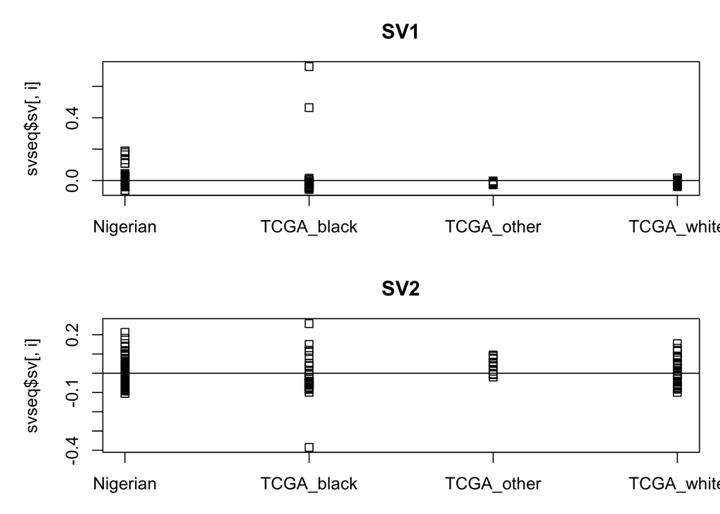

```r
par(mfrow = c(2, 1), mar = c(3,5,3,1))
for (i in 1:2) {
  stripchart(svseq$sv[, i] ~ dds$condition, vertical = TRUE, main = paste0("SV", i))
  abline(h = 0)
}
```

These are two visualization methods for seeing the differential expression results. (1) is a MAplot and (2) is a heat map.

```r
resultsNames(ddsMF)
```

```
## [1] "Intercept"                        "condition_TCGA_black_vs_Nigerian"
## [3] "condition_TCGA_other_vs_Nigerian" "condition_TCGA_white_vs_Nigerian"
```

```r
#"Intercept"                        "condition_TCGA_black_vs_Nigerian"
#"condition_TCGA_other_vs_Nigerian" "condition_TCGA_white_vs_Nigerian"
res <- lfcShrink(ddsMF, coef="condition_TCGA_white_vs_Nigerian", type="apeglm")
```

```
## using 'apeglm' for LFC shrinkage. If used in published research, please cite:
##     Zhu, A., Ibrahim, J.G., Love, M.I. (2018) Heavy-tailed prior distributions for
##     sequence count data: removing the noise and preserving large differences.
##     Bioinformatics. https://doi.org/10.1093/bioinformatics/bty895
```

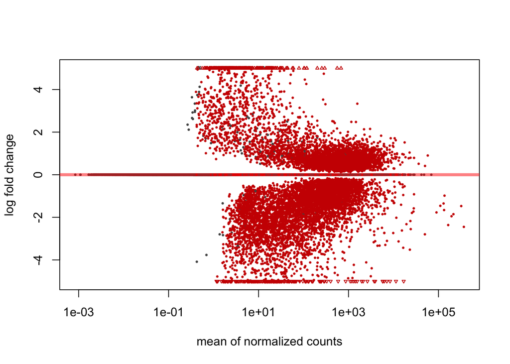

```r
plotMA(res, ylim = c(-5, 5))
```

[figure not shown]

```r
topVarGenes <- head(order(rowVars(assay(vsd)), decreasing = TRUE), 100)
mat  <- assay(vsd)[ topVarGenes, ]
mat  <- mat - rowMeans(mat)
anno <- as.data.frame(colData(vsd)[, c("condition")])
rownames(anno) <- colnames(vsd)
pheatmap(mat, annotation_col = anno)
```

Sorting the greatest differentially expressed genes and providing output.

```r
resSigwhitehead <- head(resSigwhite[ order(resSigwhite$log2FoldChange), ],100)
write.table(resSigwhitehead,"Nigerian-TCGAwhiteDiffExpGenes100-pos",sep="\t",row.names=TRUE)

resSigwhitetail <- tail(resSigwhite[order(resSigwhite$log2FoldChange), ],100)
write.table(resSigwhitetail,"Nigerian-TCGAwhiteDiffExpGenes100-pos2",sep="\t",row.names=TRUE)

resSigblackhead <- head(resSigblack[ order(resSigblack$log2FoldChange), ],100)
write.table(resSigblackhead,"Nigerian-TCGAblackDiffExpGenes100-neg",sep="\t",row.names=TRUE)

resSigblacktail <- tail(resSigblack[order(resSigblack$log2FoldChange), ],100)
write.table(resSigblacktail,"Nigerian-TCGAblackDiffExpGenes100-pos",sep="\t",row.names=TRUE)
```

R version 3.5.0 (2018-04-23) Platform: x86_64-apple-darwin15.6.0 (64-bit) Running under: macOS Sierra 10.12.5

Matrix products: default BLAS: /System/Library/Frameworks/Accelerate.framework/Versions/A/Frameworks/vecLib.framework/Versions/A/libBLAS.dylib LAPACK: /Library/Frameworks/R.framework/Versions/3.5/Resources/lib/libRlapack.dylib

locale: [1] en_US.UTF-8/en_US.UTF-8/en_US.UTF-8/C/en_US.UTF-8/en_US.UTF-8

attached base packages: [1] parallel stats4 stats graphics grDevices utils datasets methods base